# SuperKart Project

## Context:

A sales forecast is a prediction of future sales revenue based on historical data, industry trends, and the status of the current sales pipeline. Businesses use the sales forecast to estimate weekly, monthly, quarterly, and annual sales totals. It is extremely important for a company to make an accurate sales forecast as it adds value across an organization and helps the different verticals to chalk out their future course of actions. Forecasting helps an organization to plan its sales operations by regions and provide valuable insights to the supply chain team regarding the procurement of goods and materials. An accurate sales forecast process has many benefits which include improved decision-making about the future and reduction of sales pipeline and forecast risks. Moreover, it helps to reduce the time spent in planning territory coverage and establish benchmarks that can be used to assess trends in the future.

## Objective:

SuperKartKart is an organization which owns a chain of supermarkets and food marts providing a wide range of products. They want to predict the future sales revenue of its different outlets so that they can strategize their sales operation across different tier cities and plan their inventory accordingly. To achieve this purpose, SuperKart has hired a data science firm, shared the sales records of its various outlets for the previous quarter and asked the firm to come up with a suitable model to predict the total sales of the stores for the upcoming quarter.

## Data Description:

The data contains the different attributes of the various products and stores.The detailed data dictionary is given below.

- Product_Id - unique identifier of each product, each identifier having two letters at the beginning followed by a number
- Product_Weight - weight of each product
- Product_Sugar_Content - sugar content of each product like low sugar, regular and no sugar
- Product_Allocated_Area - ratio of the allocated display area of each product to the total display area of all the products in a store
- Product_Type - broad category for each product like meat, snack foods, hard drinks, dairy, canned, soft drinks, health and hygiene, baking goods, breads, breakfast, frozen foods, fruits and vegetables, household, seafood, starchy foods, others
- Product_MRP - maximum retail price of each product
- Store_Id - unique identifier of each store
- Store_Establishment_Year - year in which the store was established
- Store_Size - size of the store depending on sq. feet like high, medium and low
- Store_Location_City_Type - type of city in which the store is located like Tier 1, Tier 2 and Tier 3. Tier 1 consists of cities where the standard of living is comparatively higher than its Tier 2 and Tier 3 counterparts.
- Store_Type - type of store depending on the products that are being sold there like Departmental Store, Supermarket Type 1, Supermarket Type 2 and Food Mart
- Product_Store_Sales_Total - total revenue generated by the sale of that particular product in that particular store

## Importing necessary libraries and data

```python
# this will help in making the Python code more structured automatically (good coding practice)
%load_ext nb_black

import warnings

warnings.filterwarnings("ignore")

# Libraries to help with reading and manipulating data
import numpy as np
import pandas as pd

# Library to split data
from sklearn.model_selection import train_test_split

# libaries to help with data visualization
import matplotlib.pyplot as plt
import seaborn as sns

# Removes the limit for the number of displayed columns
pd.set_option("display.max_columns", None)
# Sets the limit for the number of displayed rows
pd.set_option("display.max_rows", 100)


# Libraries different ensemble classifiers
from sklearn.ensemble import (
    BaggingRegressor,
    RandomForestRegressor,
    AdaBoostRegressor,
    GradientBoostingRegressor,
    StackingRegressor,
)

from xgboost import XGBRegressor
from sklearn.tree import DecisionTreeRegressor

# Libraries to get different metric scores
from sklearn import metrics
from sklearn.metrics import (
    confusion_matrix,
    accuracy_score,
    precision_score,
    recall_score,
    f1_score,
)

# To tune different models
from sklearn.model_selection import GridSearchCV
from sklearn.preprocessing import StandardScaler

sc = StandardScaler()
```

## Import Dataset

```python
kart = pd.read_csv("SuperKart.csv")
```

```python
# copying data to another variable to avoid any changes to original data
data = kart.copy()
```

### View the first and last 5 rows of the dataset

```python
data.head()
```

|  | Product_Id | Product_Weight | Product_Sugar_Content | Product_Allocated_Area | Product_Type | Product_MRP | Store_Id | Store_Establishment_Year | Store_Size | Store_Location_City_Type | Store_Type | Product_Store_Sales_Total |
| --- | --- | --- | --- | --- | --- | --- | --- | --- | --- | --- | --- | --- |
| 0 | FD6114 | 12.66 | Low Sugar | 0.027 | Frozen Foods | 117.08 | OUT004 | 2009 | Medium | Tier 2 | Supermarket Type2 | 2842.40 |
| 1 | FD7839 | 16.54 | Low Sugar | 0.144 | Dairy | 171.43 | OUT003 | 1999 | Medium | Tier 1 | Departmental Store | 4830.02 |
| 2 | FD5075 | 14.28 | Regular | 0.031 | Canned | 162.08 | OUT001 | 1987 | High | Tier 2 | Supermarket Type1 | 4130.16 |
| 3 | FD8233 | 12.10 | Low Sugar | 0.112 | Baking Goods | 186.31 | OUT001 | 1987 | High | Tier 2 | Supermarket Type1 | 4132.18 |
| 4 | NC1180 | 9.57 | No Sugar | 0.010 | Health and Hygiene | 123.67 | OUT002 | 1998 | Small | Tier 3 | Food Mart | 2279.36 |

```python
data.tail()
```

|  | Product_Id | Product_Weight | Product_Sugar_Content | Product_Allocated_Area | Product_Type | Product_MRP | Store_Id | Store_Establishment_Year | Store_Size | Store_Location_City_Type | Store_Type | Product_Store_Sales_Total |
| --- | --- | --- | --- | --- | --- | --- | --- | --- | --- | --- | --- | --- |
| 8758 | NC7546 | 14.80 | No Sugar | 0.016 | Health and Hygiene | 140.53 | OUT004 | 2009 | Medium | Tier 2 | Supermarket Type2 | 3806.53 |
| 8759 | NC584 | 14.06 | No Sugar | 0.142 | Household | 144.51 | OUT004 | 2009 | Medium | Tier 2 | Supermarket Type2 | 5020.74 |
| 8760 | NC2471 | 13.48 | No Sugar | 0.017 | Health and Hygiene | 88.58 | OUT001 | 1987 | High | Tier 2 | Supermarket Type1 | 2443.42 |
| 8761 | NC7187 | 13.89 | No Sugar | 0.193 | Household | 168.44 | OUT001 | 1987 | High | Tier 2 | Supermarket Type1 | 4171.82 |
| 8762 | FD306 | 14.73 | Low Sugar | 0.177 | Snack Foods | 224.93 | OUT002 | 1998 | Small | Tier 3 | Food Mart | 2186.08 |

```python
data.sample(10)
```

|  | Product_Id | Product_Weight | Product_Sugar_Content | Product_Allocated_Area | Product_Type | Product_MRP | Store_Id | Store_Establishment_Year | Store_Size | Store_Location_City_Type | Store_Type | Product_Store_Sales_Total |
| --- | --- | --- | --- | --- | --- | --- | --- | --- | --- | --- | --- | --- |
| 7313 | FD8105 | 12.58 | Low Sugar | 0.018 | Breads | 93.84 | OUT001 | 1987 | High | Tier 2 | Supermarket Type1 | 2347.53 |
| 6497 | FD5443 | 11.53 | Regular | 0.083 | Frozen Foods | 158.53 | OUT004 | 2009 | Medium | Tier 2 | Supermarket Type2 | 3435.06 |
| 5454 | NC4324 | 12.17 | No Sugar | 0.045 | Health and Hygiene | 156.69 | OUT004 | 2009 | Medium | Tier 2 | Supermarket Type2 | 3542.16 |
| 1693 | NC255 | 13.73 | No Sugar | 0.009 | Household | 205.17 | OUT002 | 1998 | Small | Tier 3 | Food Mart | 1179.50 |
| 8318 | FD8476 | 14.18 | Regular | 0.069 | Dairy | 154.64 | OUT004 | 2009 | Medium | Tier 2 | Supermarket Type2 | 3953.36 |
| 5474 | NC6060 | 12.61 | No Sugar | 0.039 | Household | 165.19 | OUT004 | 2009 | Medium | Tier 2 | Supermarket Type2 | 3815.55 |
| 1011 | FD3106 | 14.03 | Regular | 0.048 | Dairy | 144.28 | OUT004 | 2009 | Medium | Tier 2 | Supermarket Type2 | 3708.97 |
| 5456 | NC791 | 13.78 | No Sugar | 0.012 | Others | 154.90 | OUT004 | 2009 | Medium | Tier 2 | Supermarket Type2 | 3868.43 |
| 1920 | FD6715 | 13.30 | Regular | 0.076 | Dairy | 138.01 | OUT004 | 2009 | Medium | Tier 2 | Supermarket Type2 | 3415.46 |
| 8639 | FD7740 | 12.64 | Low Sugar | 0.019 | Dairy | 165.51 | OUT004 | 2009 | Medium | Tier 2 | Supermarket Type2 | 3828.37 |

### Understand the shape of the dataset

```python
data.shape
```

```
(8763, 12)
```

### Check the data types of the columns for the dataset

```python
data.dtypes
```

```
Product_Id                    object
Product_Weight               float64
Product_Sugar_Content         object
Product_Allocated_Area       float64
Product_Type                  object
Product_MRP                  float64
Store_Id                      object
Store_Establishment_Year       int64
Store_Size                    object
Store_Location_City_Type      object
Store_Type                    object
Product_Store_Sales_Total    float64
dtype: object
```

```python
data.info()
```

```
<class 'pandas.core.frame.DataFrame'>
RangeIndex: 8763 entries, 0 to 8762
Data columns (total 12 columns):
 #   Column                     Non-Null Count  Dtype
---  ------                     --------------  -----
 0   Product_Id                 8763 non-null   object
 1   Product_Weight             8763 non-null   float64
 2   Product_Sugar_Content      8763 non-null   object
 3   Product_Allocated_Area     8763 non-null   float64
 4   Product_Type               8763 non-null   object
 5   Product_MRP                8763 non-null   float64
 6   Store_Id                   8763 non-null   object
 7   Store_Establishment_Year   8763 non-null   int64
 8   Store_Size                 8763 non-null   object
 9   Store_Location_City_Type   8763 non-null   object
 10  Store_Type                 8763 non-null   object
 11  Product_Store_Sales_Total  8763 non-null   float64
dtypes: float64(4), int64(1), object(7)
memory usage: 821.7+ KB
```

## Exploratory Data Analysis

### Let's check the statistical summary of the data.

```python
# creating two separate dataframes for categorical and numerical features.

categorical_features = data.select_dtypes(include="object")
numerical_features = data.select_dtypes(exclude="object")
```

```python
# showing some statistical analysis of the data like mean, std, min, max, and, count for the numeric features.

data.describe()
```

|  | Product_Weight | Product_Allocated_Area | Product_MRP | Store_Establishment_Year | Product_Store_Sales_Total |
| --- | --- | --- | --- | --- | --- |
| count | 8763.000000 | 8763.000000 | 8763.000000 | 8763.000000 | 8763.000000 |
| mean | 12.653792 | 0.068786 | 147.032539 | 2002.032751 | 3464.003640 |
| std | 2.217320 | 0.048204 | 30.694110 | 8.388381 | 1065.630494 |
| min | 4.000000 | 0.004000 | 31.000000 | 1987.000000 | 33.000000 |
| 25% | 11.150000 | 0.031000 | 126.160000 | 1998.000000 | 2761.715000 |
| 50% | 12.660000 | 0.056000 | 146.740000 | 2009.000000 | 3452.340000 |
| 75% | 14.180000 | 0.096000 | 167.585000 | 2009.000000 | 4145.165000 |
| max | 22.000000 | 0.298000 | 266.000000 | 2009.000000 | 8000.000000 |

```python
# showing some statistical analysis of the data like unique, top, frequency, and, count for the categorical features.

data.describe(include="object")
```

|  | Product_Id | Product_Sugar_Content | Product_Type | Store_Id | Store_Size | Store_Location_City_Type | Store_Type |
| --- | --- | --- | --- | --- | --- | --- | --- |
| count | 8763 | 8763 | 8763 | 8763 | 8763 | 8763 | 8763 |
| unique | 8763 | 4 | 16 | 4 | 3 | 3 | 4 |
| top | FD6114 | Low Sugar | Fruits and Vegetables | OUT004 | Medium | Tier 2 | Supermarket Type2 |
| freq | 1 | 4885 | 1249 | 4676 | 6025 | 6262 | 4676 |

### Let's check the count of each unique category in each of the categorical variables.

```python
# Making a list of all catrgorical variables
cat_col = list(data.select_dtypes("object").columns)

# Printing number of count of each unique value in each column
for column in cat_col:
    print(data[column].value_counts())
    print("-" * 50)
```

```
FD6114    1
FD8349    1
DR3530    1
NC5926    1
FD3575    1
         ..
FD2396    1
FD681     1
FD8077    1
DR3118    1
FD306     1
Name: Product_Id, Length: 8763, dtype: int64
--------------------------------------------------
Low Sugar    4885
Regular      2251
No Sugar     1519
reg           108
Name: Product_Sugar_Content, dtype: int64
--------------------------------------------------
Fruits and Vegetables    1249
Snack Foods              1149
Frozen Foods              811
Dairy                     796
Household                 740
Baking Goods              716
Canned                    677
Health and Hygiene        628
Meat                      618
Soft Drinks               519
Breads                    200
Hard Drinks               186
Others                    151
Starchy Foods             141
Breakfast                 106
Seafood                    76
Name: Product_Type, dtype: int64
--------------------------------------------------
OUT004    4676
OUT001    1586
OUT003    1349
OUT002    1152
Name: Store_Id, dtype: int64
--------------------------------------------------
Medium    6025
High      1586
Small     1152
Name: Store_Size, dtype: int64
--------------------------------------------------
Tier 2    6262
Tier 1    1349
Tier 3    1152
Name: Store_Location_City_Type, dtype: int64
--------------------------------------------------
Supermarket Type2     4676
Supermarket Type1     1586
Departmental Store    1349
Food Mart             1152
Name: Store_Type, dtype: int64
--------------------------------------------------
```

```python
# Replacing reg with Regular
data.Product_Sugar_Content.replace(to_replace=["reg"], value=["Regular"], inplace=True)
```

```python
data.Product_Sugar_Content.count()  # Fill the blank to count values for each class in Product_Sugar_Content
```

```
8763
```

```python
## extracting the first two characters from the Product_Id column and storing it in another column
data["Product_Id_char"] = data["Product_Id"].str[:2]
data.head()
```

|  | Product_Id | Product_Weight | Product_Sugar_Content | Product_Allocated_Area | Product_Type | Product_MRP | Store_Id | Store_Establishment_Year | Store_Size | Store_Location_City_Type | Store_Type | Product_Store_Sales_Total | Product_Id_char |
| --- | --- | --- | --- | --- | --- | --- | --- | --- | --- | --- | --- | --- | --- |
| 0 | FD6114 | 12.66 | Low Sugar | 0.027 | Frozen Foods | 117.08 | OUT004 | 2009 | Medium | Tier 2 | Supermarket Type2 | 2842.40 | FD |
| 1 | FD7839 | 16.54 | Low Sugar | 0.144 | Dairy | 171.43 | OUT003 | 1999 | Medium | Tier 1 | Departmental Store | 4830.02 | FD |
| 2 | FD5075 | 14.28 | Regular | 0.031 | Canned | 162.08 | OUT001 | 1987 | High | Tier 2 | Supermarket Type1 | 4130.16 | FD |
| 3 | FD8233 | 12.10 | Low Sugar | 0.112 | Baking Goods | 186.31 | OUT001 | 1987 | High | Tier 2 | Supermarket Type1 | 4132.18 | FD |
| 4 | NC1180 | 9.57 | No Sugar | 0.010 | Health and Hygiene | 123.67 | OUT002 | 1998 | Small | Tier 3 | Food Mart | 2279.36 | NC |

```python
data[
    "Product_Id_char"
].unique()  # Fill the blank to get all unique elements in Product_Id_char
```

```
array(['FD', 'NC', 'DR'], dtype=object)
```

```python
data.loc[
    data.Product_Id_char == "FD", "Product_Type"
].unique()  # Fill the blank to get all unique elements
```

```
array(['Frozen Foods', 'Dairy', 'Canned', 'Baking Goods', 'Snack Foods',
       'Meat', 'Fruits and Vegetables', 'Breads', 'Breakfast',
       'Starchy Foods', 'Seafood'], dtype=object)
```

```python
data.loc[
    data.Product_Id_char == "DR", "Product_Type"
].unique()  # Fill the blank to get all unique elements
```

```
array(['Hard Drinks', 'Soft Drinks'], dtype=object)
```

```python
data.loc[
    data.Product_Id_char == "NC", "Product_Type"
].unique()  # Fill the blank to get all unique elements
```

```
array(['Health and Hygiene', 'Household', 'Others'], dtype=object)
```

### The Product_Id column will not add any value to our analysis so let's drop it before we move forward.

```python
## dropping the column
data = data.drop(["Product_Id"], axis=1)  # Fill the blank to drop the Product_Id column
```

```python
data.head()
```

|  | Product_Weight | Product_Sugar_Content | Product_Allocated_Area | Product_Type | Product_MRP | Store_Id | Store_Establishment_Year | Store_Size | Store_Location_City_Type | Store_Type | Product_Store_Sales_Total | Product_Id_char |
| --- | --- | --- | --- | --- | --- | --- | --- | --- | --- | --- | --- | --- |
| 0 | 12.66 | Low Sugar | 0.027 | Frozen Foods | 117.08 | OUT004 | 2009 | Medium | Tier 2 | Supermarket Type2 | 2842.40 | FD |
| 1 | 16.54 | Low Sugar | 0.144 | Dairy | 171.43 | OUT003 | 1999 | Medium | Tier 1 | Departmental Store | 4830.02 | FD |
| 2 | 14.28 | Regular | 0.031 | Canned | 162.08 | OUT001 | 1987 | High | Tier 2 | Supermarket Type1 | 4130.16 | FD |
| 3 | 12.10 | Low Sugar | 0.112 | Baking Goods | 186.31 | OUT001 | 1987 | High | Tier 2 | Supermarket Type1 | 4132.18 | FD |
| 4 | 9.57 | No Sugar | 0.010 | Health and Hygiene | 123.67 | OUT002 | 1998 | Small | Tier 3 | Food Mart | 2279.36 | NC |

### Exploratory Data Analysis and Insights

- Use appropriate visualizations to identify the patterns and insights - Key meaningful observations on individual variables and the relationship between variables Problem definition
- Sales forecasting is the process of predicting how much revenue a company, team, or person will generate within a specific timeframe. Every organization or company wants to make an accurate and valid sales forecast because it is very helpful in making many decisions. An accurate sales forecast allows and helps companies to efficiently allocate resources for their future growth and manage their cash flow.
- Sales forecasting is both a science and an art. Decision makers rely on these forecasts to plan for business expansion and to determine how to fuel the company’s growth. So, in many ways, sales forecasting affects everyone in the organization
- EDA is an important part of any project involving data.
- It is important to investigate and understand the data better before building a model with it.
- A few questions have been mentioned below which will help you approach the analysis in the right manner and generate insights from the data.
- A thorough analysis of the data, in addition to the questions mentioned below, should be done.

Questions

- Different varieties of products are available at stores. A store needs to plan its inventory appropriately which is well aligned to the supply and demand characteristics. Which product type is contributing the most to the revenue of the company (SuperKart)?
- Location may have a high impact on the revenue of a store. Find out the type of stores and locations that are having a high impact on the revenue of the company.
- Nowadays many customers prefer products that have low sugar content in them. How many items have been sold in each of the 16 product types that have low sugar content in them?
- Which product type has been sold the most number of times in each of the stores? Which product type is contributing the most to the revenue of the individual stores?
- There are some stores of a company that generally sell only premium items having higher prices than others. Which store has sold more costly goods than others?

### Univariate analysis

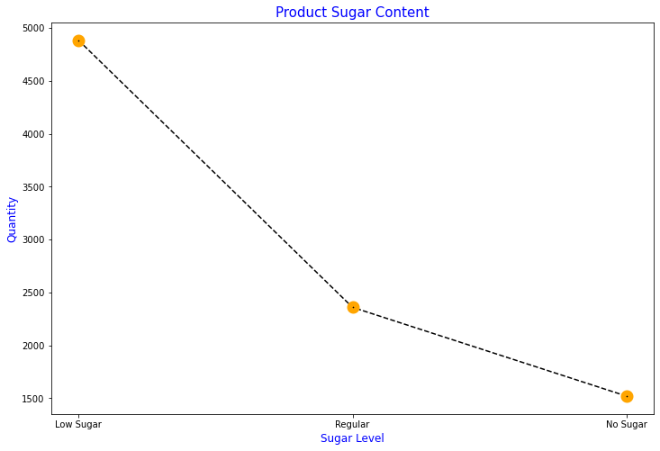

```python
plt.figure(figsize=(12, 8))
plt.plot(
    data.Product_Sugar_Content.value_counts(),
    marker="o",
    mec="orange",
    mew=8,
    ls="--",
    c="k",
)
plt.title("Product Sugar Content", fontsize=15, color="b")
plt.xlabel("Sugar Level", fontsize=12, color="b")
plt.ylabel("Quantity", fontsize=12, color="b")
plt.show()
```

- From the above graph we can tell that more than half of the products have Low Sugar.

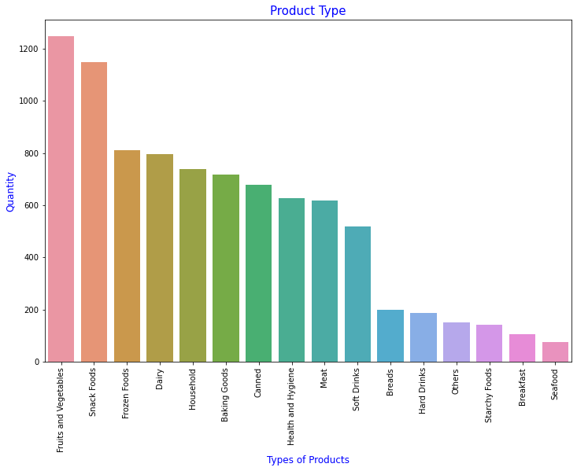

```python
plt.figure(figsize=(12, 8))
sns.countplot(
    categorical_features.Product_Type,
    order=categorical_features.Product_Type.value_counts().index,
)
plt.title("Product Type", fontsize=15, color="b")
plt.xlabel("Types of Products", fontsize=12, color="b")
plt.ylabel("Quantity", fontsize=12, color="b")
plt.xticks(rotation=90)
plt.show()
```

- Fruits and Vegetables, Snack Foods, Frozen Foods, and Dairy are the most sold products and these four products alone cover almost 50% of the sold products. This makes sense because these are the items that are used on daily basis i.e. Fruits and Vegetables and Dairy.

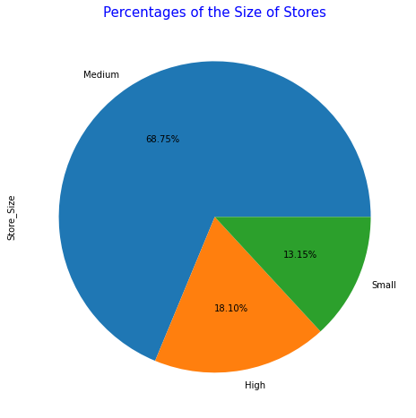

```python
data.Store_Size.value_counts().plot(
    kind="pie", legend=False, autopct="%1.2f%%", fontsize=10, figsize=(8, 8)
)
plt.title("Percentages of the Size of Stores", loc="center", c="b", size=15)
plt.show()
```

- The given dataset had 3 types of Store Size among which medium size store were 68.75%. Most of the stores are medium in size.

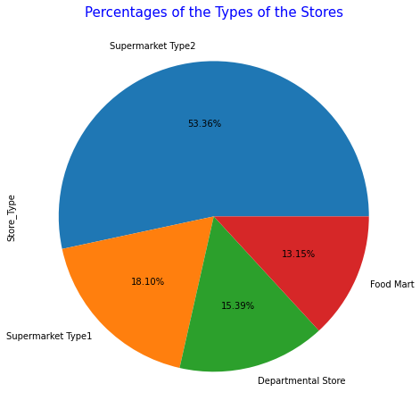

```python
data.Store_Type.value_counts().plot(
    kind="pie", legend=False, autopct="%1.2f%%", fontsize=10, figsize=(8, 8)
)
plt.title("Percentages of the Types of the Stores", loc="center", c="b", size=15)
plt.show()
```

- Most of the type of store is Super Market because almost 72% of the stores are type of Supermarket, either Supermaket type1 or Supermarket type 2

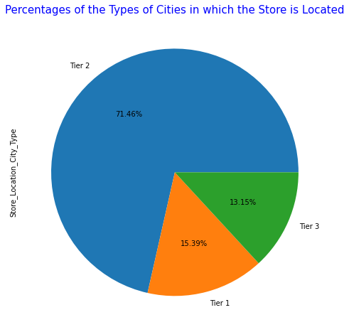

```python
data.Store_Location_City_Type.value_counts().plot(
    kind="pie", legend=False, autopct="%1.2f%%", fontsize=10, figsize=(8, 8)
)
plt.title(
    "Percentages of the Types of Cities in which the Store is Located",
    loc="center",
    c="b",
    size=15,
)
plt.show()
```

- Most of the stores are located in Tier 2. Tier 2 alone covers 71% of all the stores.

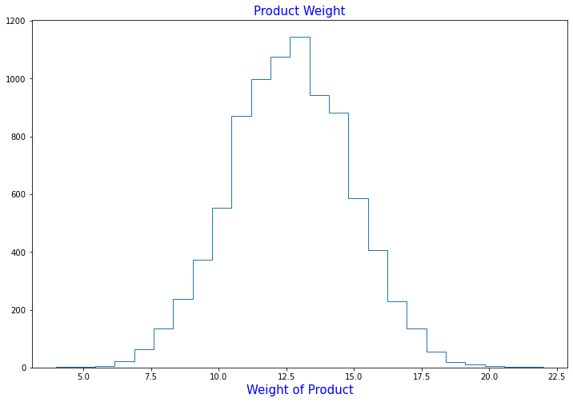

```python
plt.figure(figsize=(12, 8))
plt.hist(numerical_features.Product_Weight, histtype="step", bins=25)
plt.title("Product Weight", size=15, c="b")
plt.xlabel("Weight of Product", size=15, c="b")
plt.show()
```

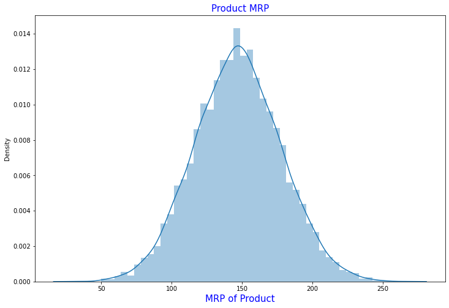

```python
plt.figure(figsize=(12, 8))
sns.distplot(numerical_features.Product_MRP)
plt.title("Product MRP", size=15, c="b")
plt.xlabel("MRP of Product", size=15, c="b")
plt.show()
```

```python
# function to plot a boxplot and a histogram along the same scale.


def histogram_boxplot(data, feature, figsize=(12, 7), kde=False, bins=None):
    """
    Boxplot and histogram combined

    data: dataframe
    feature: dataframe column
    figsize: size of figure (default (12,7))
    kde: whether to the show density curve (default False)
    bins: number of bins for histogram (default None)
    """
    f2, (ax_box2, ax_hist2) = plt.subplots(
        nrows=2,  # Number of rows of the subplot grid= 2
        sharex=True,  # x-axis will be shared among all subplots
        gridspec_kw={"height_ratios": (0.25, 0.75)},
        figsize=figsize,
    )  # creating the 2 subplots
    sns.boxplot(
        data=data, x=feature, ax=ax_box2, showmeans=True, color="violet"
    )  # boxplot will be created and a star will indicate the mean value of the column
    sns.histplot(
        data=data, x=feature, kde=kde, ax=ax_hist2, bins=bins, palette="winter"
    ) if bins else sns.histplot(
        data=data, x=feature, kde=kde, ax=ax_hist2
    )  # For histogram
    ax_hist2.axvline(
        data[feature].mean(), color="green", linestyle="--"
    )  # Add mean to the histogram
    ax_hist2.axvline(
        data[feature].median(), color="black", linestyle="-"
    )  # Add median to the histogram
```

**Product_Allocated_Area**

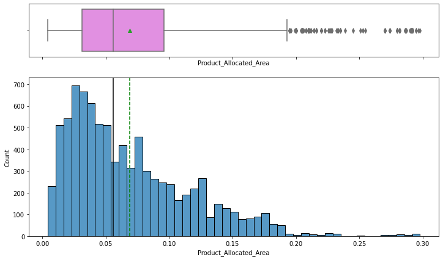

```python
histogram_boxplot(data, "Product_Allocated_Area")
```

**Product_Store_Sales_Total**

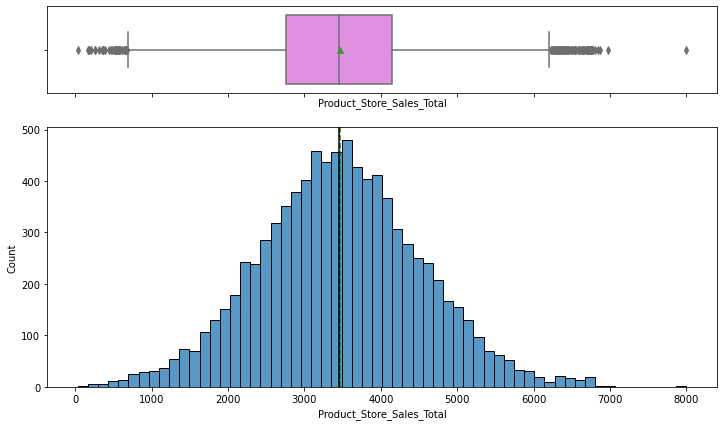

```python
histogram_boxplot(data, "Product_Store_Sales_Total")
```

```python
# function to create labeled barplots


def labeled_barplot(data, feature, perc=False, n=None):
    """
    Barplot with percentage at the top

    data: dataframe
    feature: dataframe column
    perc: whether to display percentages instead of count (default is False)
    n: displays the top n category levels (default is None, i.e., display all levels)
    """

    total = len(data[feature])  # length of the column
    count = data[feature].nunique()
    if n is None:
        plt.figure(figsize=(count + 1, 5))
    else:
        plt.figure(figsize=(n + 1, 5))

    plt.xticks(rotation=90, fontsize=15)
    ax = sns.countplot(
        data=data,
        x=feature,
        palette="Paired",
        order=data[feature].value_counts().index[:n].sort_values(),
    )

    for p in ax.patches:
        if perc == True:
            label = "{:.1f}%".format(
                100 * p.get_height() / total
            )  # percentage of each class of the category
        else:
            label = p.get_height()  # count of each level of the category

        x = p.get_x() + p.get_width() / 2  # width of the plot
        y = p.get_height()  # height of the plot

        ax.annotate(
            label,
            (x, y),
            ha="center",
            va="center",
            size=12,
            xytext=(0, 5),
            textcoords="offset points",
        )  # annotate the percentage

    plt.show()  # show the plot
```

**Store_Id**

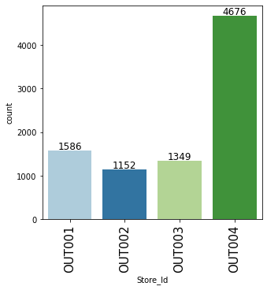

```python
labeled_barplot(data, "Store_Id")
```

### Bivariate analysis

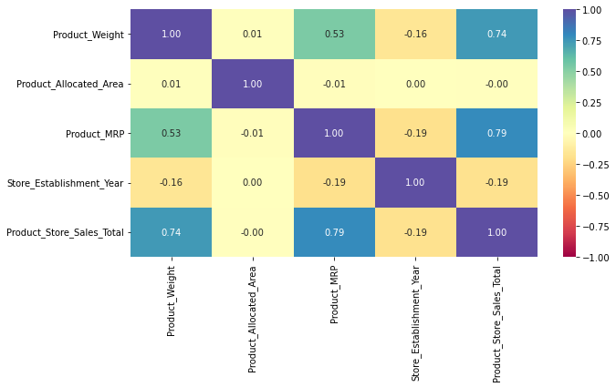

```python
cols_list = data.select_dtypes(include=np.number).columns.tolist()

plt.figure(figsize=(10, 5))
sns.heatmap(
    data[cols_list].corr(), annot=True, vmin=-1, vmax=1, fmt=".2f", cmap="Spectral"
)
plt.show()
```

**Let's check the distribution of our target variable i.e Product_Store_Sales_Total with the numeric columns**

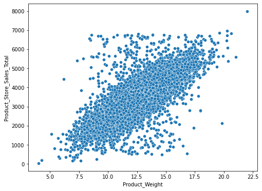

```python
plt.figure(figsize=[8, 6])
sns.scatterplot(x=data.Product_Weight, y=data.Product_Store_Sales_Total)
plt.show()
```

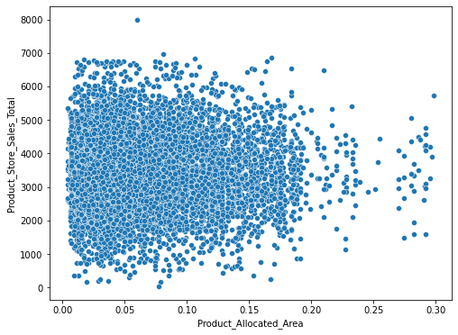

```python
plt.figure(figsize=[8, 6])
sns.scatterplot(x=data.Product_Allocated_Area, y=data.Product_Store_Sales_Total)
```

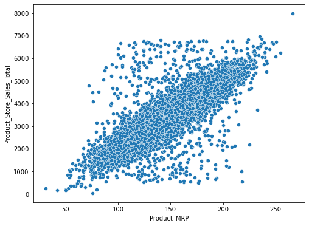

```python
plt.figure(figsize=[8, 6])
sns.scatterplot(x=data.Product_MRP, y=data.Product_Store_Sales_Total)
plt.show()
```

**Let us see from which product type the company is generating most of the revenue**

- Q: Different varieties of products are available at stores. A store needs to plan its inventory appropriately which is well aligned to the supply and demand characteristics. Which product type is contributing the most to the revenue of the company (SuperKart)?

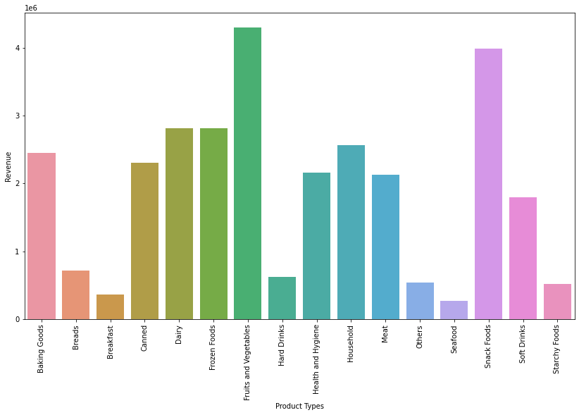

```python
df_revenue1 = data.groupby(["Product_Type"], as_index=False)[
    "Product_Store_Sales_Total"
].sum()
plt.figure(figsize=[14, 8])
plt.xticks(rotation=90)
a = sns.barplot(x=df_revenue1.Product_Type, y=df_revenue1.Product_Store_Sales_Total)
a.set_xlabel("Product Types")
a.set_ylabel("Revenue")
plt.show()
```

- Fruits and Vegetables, Snack Foods, Frozen Foods, and Dairy are the products which are contibuting to most of the revenue and these four products alone cover almost 50% of the sold products. This makes sense because these are the items that are used on daily basis i.e. Fruits and Vegetables and Dairy.

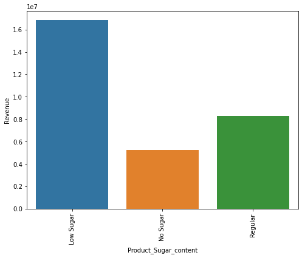

```python
df_revenue2 = data.groupby(["Product_Sugar_Content"], as_index=False)[
    "Product_Store_Sales_Total"
].sum()
plt.figure(figsize=[8, 6])
plt.xticks(rotation=90)
b = sns.barplot(
    x=df_revenue2.Product_Sugar_Content, y=df_revenue2.Product_Store_Sales_Total
)
b.set_xlabel("Product_Sugar_content")
b.set_ylabel("Revenue")
plt.show()
```

**Let us see from which type of stores and locations the revenue generation is more**.

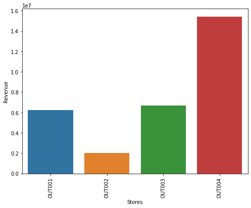

```python
df_store_revenue = data.groupby(["Store_Id"], as_index=False)[
    "Product_Store_Sales_Total"
].sum()
plt.figure(figsize=[8, 6])
plt.xticks(rotation=90)
r = sns.barplot(
    x=df_store_revenue.Store_Id, y=df_store_revenue.Product_Store_Sales_Total
)  # Fill the blank to plot bar plot with Store_Id as x and Product_Store_Sales_Total as y
r.set_xlabel("Stores")
r.set_ylabel("Revenue")
plt.show()
```

- The above plot shows that the store_id OUT004 generates most of the revenue.

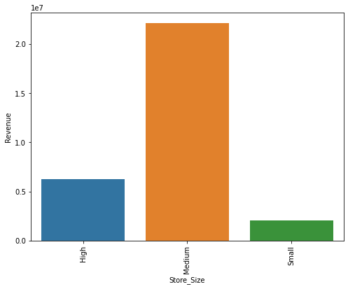

```python
df_revenue3 = data.groupby(["Store_Size"], as_index=False)[
    "Product_Store_Sales_Total"
].sum()
plt.figure(figsize=[8, 6])
plt.xticks(rotation=90)
c = sns.barplot(df_revenue3.Store_Size, y=df_revenue3.Product_Store_Sales_Total)
c.set_xlabel("Store_Size")
c.set_ylabel("Revenue")
plt.show()
```

- Plot shows that the medium store_size mostly contributes to generate revenue as it can accommodate more products.
- Q: Location may have a high impact on the revenue of a store. Find out the type of stores and locations that are having a high impact on the revenue of the company.

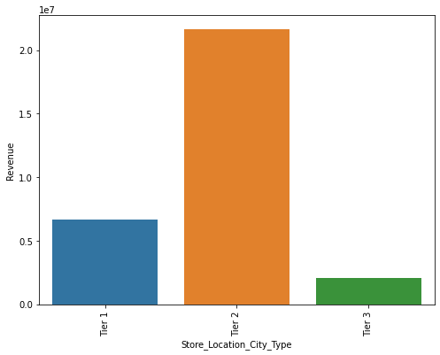

```python
df_revenue4 = data.groupby(["Store_Location_City_Type"], as_index=False)[
    "Product_Store_Sales_Total"
].sum()
plt.figure(figsize=[8, 6])
plt.xticks(rotation=90)
d = sns.barplot(
    df_revenue4.Store_Location_City_Type, y=df_revenue4.Product_Store_Sales_Total
)  # Fill the blank to plot bar plot with Store_Location_City_Type as x and Product_Store_Sales_Total as y
d.set_xlabel("Store_Location_City_Type")
d.set_ylabel("Revenue")
plt.show()
```

- Plot shows that store_location Tier2 and medium size of the stores generate most revenue to the company

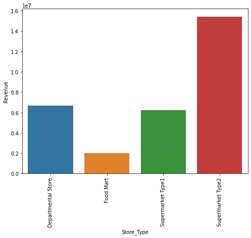

```python
df_revenue5 = data.groupby(["Store_Type"], as_index=False)[
    "Product_Store_Sales_Total"
].sum()
plt.figure(figsize=[8, 6])
plt.xticks(rotation=90)
e = sns.barplot(x=df_revenue5.Store_Type, y=df_revenue5.Product_Store_Sales_Total)
e.set_xlabel("Store_Type")
e.set_ylabel("Revenue")
plt.show()
```

- Plot shows that store_location Tier2 and Supermarket type 2 of the stores generate most revenue to the company

**Let's check the distribution of our target variable i.e Product_Store_Sales_Total with the other categorical columns**

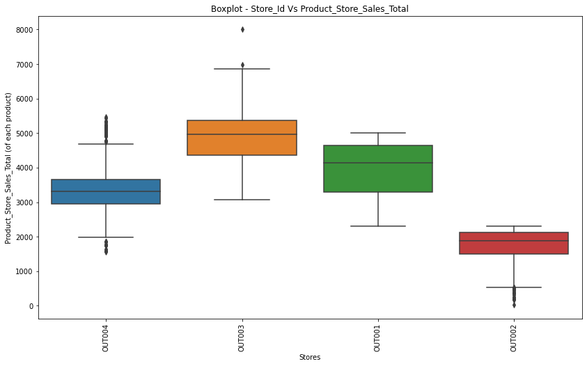

```python
plt.figure(figsize=[14, 8])
sns.boxplot(data.Store_Id, data.Product_Store_Sales_Total)
plt.xticks(rotation=90)
plt.title("Boxplot - Store_Id Vs Product_Store_Sales_Total")
plt.xlabel("Stores")
plt.ylabel("Product_Store_Sales_Total (of each product)")
plt.show()
```

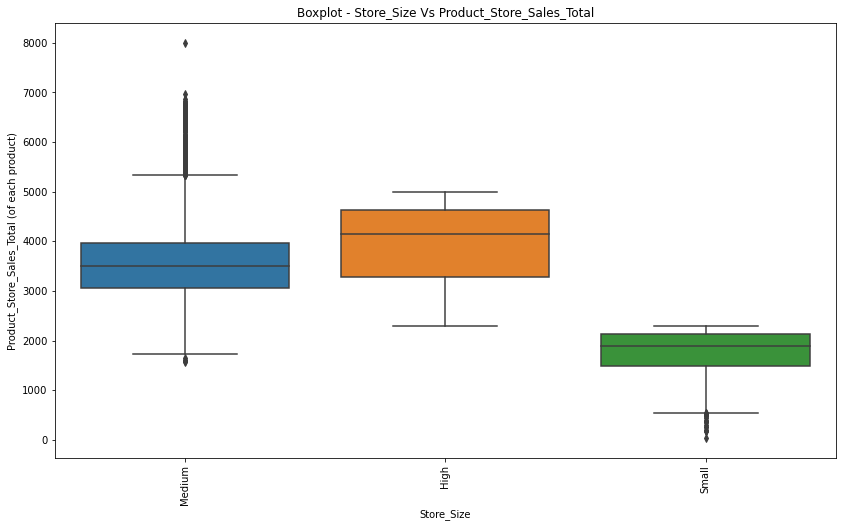

```python
plt.figure(figsize=[14, 8])
sns.boxplot(
    data.Store_Size, data.Product_Store_Sales_Total
)  # Fill the blank to plot boxplot of Store size against Product_Store_Sales_Total
plt.xticks(rotation=90)
plt.title("Boxplot - Store_Size Vs Product_Store_Sales_Total")
plt.xlabel("Store_Size")
plt.ylabel("Product_Store_Sales_Total (of each product)")
plt.show()
```

**Let's now try to find out some relationship between the other columns**

**Generally certain product types will have higher product weight than others. Let's have a look.**

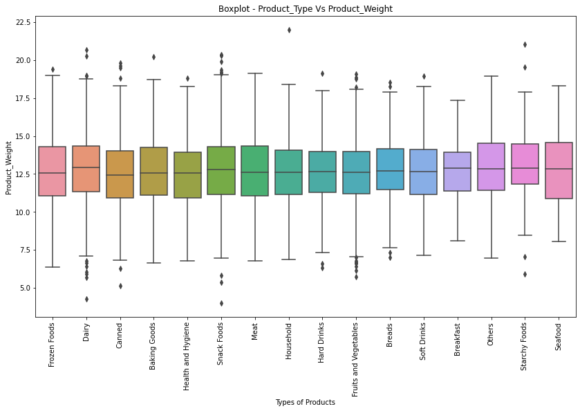

```python
plt.figure(figsize=[14, 8])
sns.boxplot(
    data.Product_Type, data.Product_Weight
)  # Fill the blank to plot boxplot of Product_Type against Product_Weight
plt.xticks(rotation=90)
plt.title("Boxplot - Product_Type Vs Product_Weight")
plt.xlabel("Types of Products")
plt.ylabel("Product_Weight")
plt.show()
```

**Let's find out whether there is some relationship between the weight of the product and its sugar content**

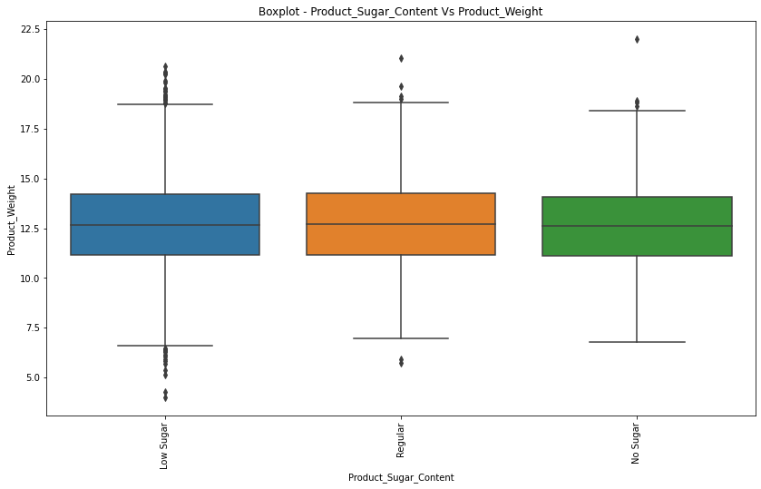

```python
plt.figure(figsize=[14, 8])
sns.boxplot(data.Product_Sugar_Content, data.Product_Weight)
plt.xticks(rotation=90)
plt.title("Boxplot - Product_Sugar_Content Vs Product_Weight")
plt.xlabel("Product_Sugar_Content")
plt.ylabel("Product_Weight")
plt.show()
```

- Q: Nowadays many customers prefer products that have low sugar content in them. How many items have been sold in each of the 16 product types that have low sugar content in them?

**Let's analyze the sugar content of different product types**

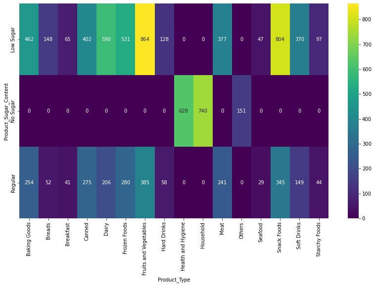

```python
plt.figure(figsize=(14, 8))
sns.heatmap(
    pd.crosstab(data["Product_Sugar_Content"], data["Product_Type"]),
    annot=True,
    fmt="g",
    cmap="viridis",
)
plt.ylabel("Product_Sugar_Content")
plt.xlabel("Product_Type")
plt.show()
```

- Q: There are some stores of a company that generally sell only premium items having higher prices than others. Which store has sold more costly goods than others?

**Different product types have different prices. Let's analyze the trend.**

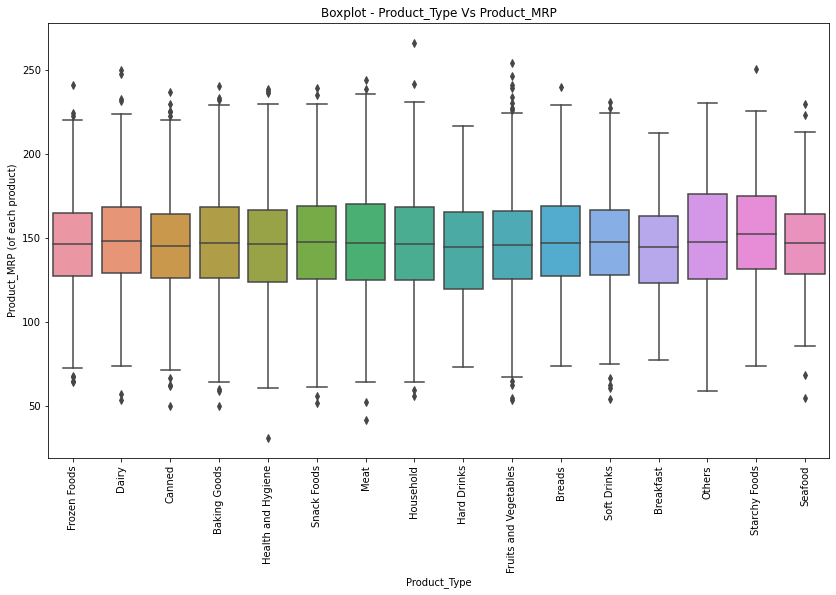

```python
plt.figure(figsize=[14, 8])
sns.boxplot(data.Product_Type, data.Product_MRP)
plt.xticks(rotation=90)
plt.title("Boxplot - Product_Type Vs Product_MRP")
plt.xlabel("Product_Type")
plt.ylabel("Product_MRP (of each product)")
plt.show()
```

**Let's find out how the Product_MRP varies with the different stores**

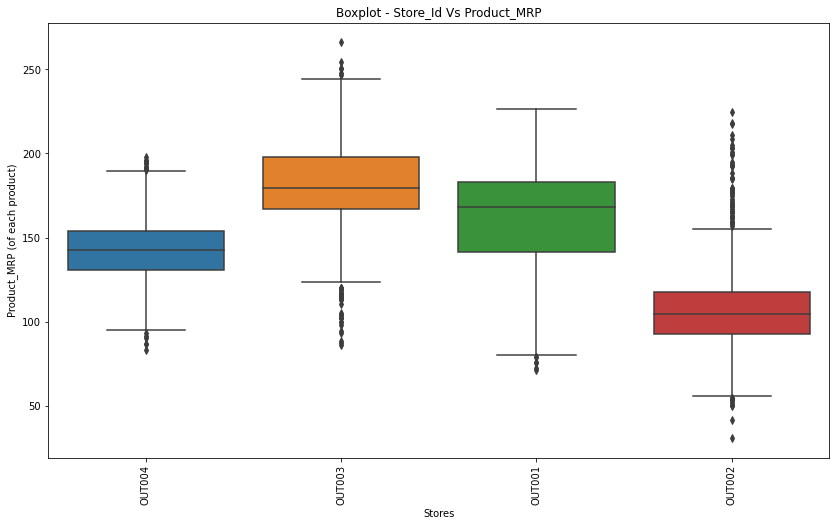

```python
plt.figure(figsize=[14, 8])
sns.boxplot(data.Store_Id, data.Product_MRP)
plt.xticks(rotation=90)
plt.title("Boxplot - Store_Id Vs Product_MRP")
plt.xlabel("Stores")
plt.ylabel("Product_MRP (of each product)")
plt.show()
```

**Let's delve deeper and do a detailed analysis of each of the stores**.

#### OUT001

```python
data.loc[data["Store_Id"] == "OUT001"].describe(include="all").T
```

|  | count | unique | top | freq | mean | std | min | 25% | 50% | 75% | max |
| --- | --- | --- | --- | --- | --- | --- | --- | --- | --- | --- | --- |
| Product_Weight | 1586.0 | NaN | NaN | NaN | 13.458865 | 2.064975 | 6.16 | 12.0525 | 13.96 | 14.95 | 17.97 |
| Product_Sugar_Content | 1586 | 3 | Low Sugar | 845 | NaN | NaN | NaN | NaN | NaN | NaN | NaN |
| Product_Allocated_Area | 1586.0 | NaN | NaN | NaN | 0.068768 | 0.047131 | 0.004 | 0.033 | 0.0565 | 0.094 | 0.295 |
| Product_Type | 1586 | 16 | Snack Foods | 202 | NaN | NaN | NaN | NaN | NaN | NaN | NaN |
| Product_MRP | 1586.0 | NaN | NaN | NaN | 160.514054 | 30.359059 | 71.35 | 141.72 | 168.32 | 182.9375 | 226.59 |
| Store_Id | 1586 | 1 | OUT001 | 1586 | NaN | NaN | NaN | NaN | NaN | NaN | NaN |
| Store_Establishment_Year | 1586.0 | NaN | NaN | NaN | 1987.0 | 0.0 | 1987.0 | 1987.0 | 1987.0 | 1987.0 | 1987.0 |
| Store_Size | 1586 | 1 | High | 1586 | NaN | NaN | NaN | NaN | NaN | NaN | NaN |
| Store_Location_City_Type | 1586 | 1 | Tier 2 | 1586 | NaN | NaN | NaN | NaN | NaN | NaN | NaN |
| Store_Type | 1586 | 1 | Supermarket Type1 | 1586 | NaN | NaN | NaN | NaN | NaN | NaN | NaN |
| Product_Store_Sales_Total | 1586.0 | NaN | NaN | NaN | 3923.778802 | 904.62901 | 2300.56 | 3285.51 | 4139.645 | 4639.4 | 4997.63 |
| Product_Id_char | 1586 | 3 | FD | 1163 | NaN | NaN | NaN | NaN | NaN | NaN | NaN |

```python
data.loc[data["Store_Id"] == "OUT001", "Product_Store_Sales_Total"].sum()
```

```
6223113.18
```

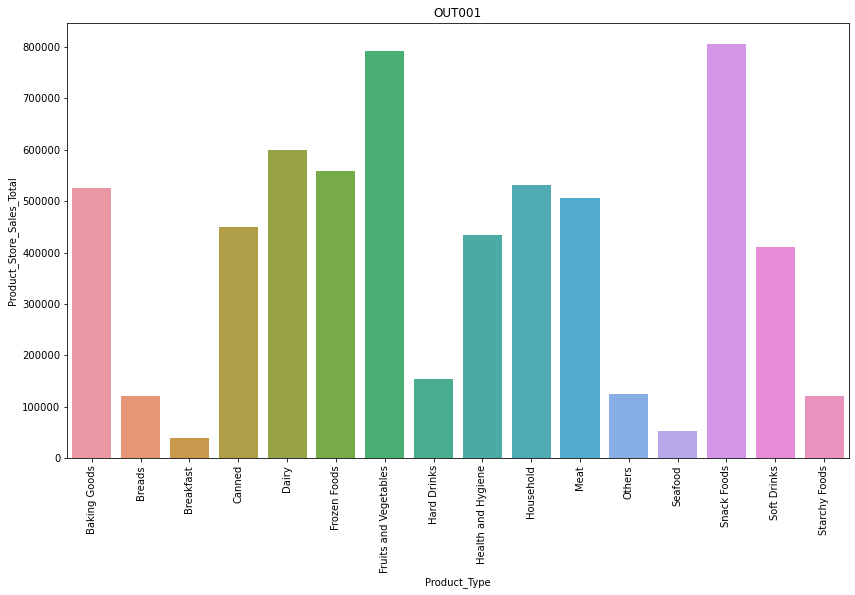

```python
df_OUT001 = (
    data.loc[data["Store_Id"] == "OUT001"]
    .groupby(["Product_Type"], as_index=False)["Product_Store_Sales_Total"]
    .sum()
)
plt.figure(figsize=[14, 8])
plt.xticks(rotation=90)
plt.xlabel("Product_Type")
plt.ylabel("Product_Store_Sales_Total")
plt.title("OUT001")
sns.barplot(x=df_OUT001.Product_Type, y=df_OUT001.Product_Store_Sales_Total)
plt.show()
```

#### OUT002

```python
data.loc[data["Store_Id"] == "OUT002"].describe(include="all").T
```

|  | count | unique | top | freq | mean | std | min | 25% | 50% | 75% | max |
| --- | --- | --- | --- | --- | --- | --- | --- | --- | --- | --- | --- |
| Product_Weight | 1152.0 | NaN | NaN | NaN | 9.911241 | 1.799846 | 4.0 | 8.7675 | 9.795 | 10.89 | 19.82 |
| Product_Sugar_Content | 1152 | 3 | Low Sugar | 658 | NaN | NaN | NaN | NaN | NaN | NaN | NaN |
| Product_Allocated_Area | 1152.0 | NaN | NaN | NaN | 0.067747 | 0.047567 | 0.006 | 0.031 | 0.0545 | 0.09525 | 0.292 |
| Product_Type | 1152 | 16 | Fruits and Vegetables | 168 | NaN | NaN | NaN | NaN | NaN | NaN | NaN |
| Product_MRP | 1152.0 | NaN | NaN | NaN | 107.080634 | 24.912333 | 31.0 | 92.8275 | 104.675 | 117.8175 | 224.93 |
| Store_Id | 1152 | 1 | OUT002 | 1152 | NaN | NaN | NaN | NaN | NaN | NaN | NaN |
| Store_Establishment_Year | 1152.0 | NaN | NaN | NaN | 1998.0 | 0.0 | 1998.0 | 1998.0 | 1998.0 | 1998.0 | 1998.0 |
| Store_Size | 1152 | 1 | Small | 1152 | NaN | NaN | NaN | NaN | NaN | NaN | NaN |
| Store_Location_City_Type | 1152 | 1 | Tier 3 | 1152 | NaN | NaN | NaN | NaN | NaN | NaN | NaN |
| Store_Type | 1152 | 1 | Food Mart | 1152 | NaN | NaN | NaN | NaN | NaN | NaN | NaN |
| Product_Store_Sales_Total | 1152.0 | NaN | NaN | NaN | 1762.942465 | 462.862431 | 33.0 | 1495.4725 | 1889.495 | 2133.6225 | 2299.63 |
| Product_Id_char | 1152 | 3 | FD | 850 | NaN | NaN | NaN | NaN | NaN | NaN | NaN |

```python
data.loc[data["Store_Id"] == "OUT002", "Product_Store_Sales_Total"].sum()
```

```
2030909.72
```

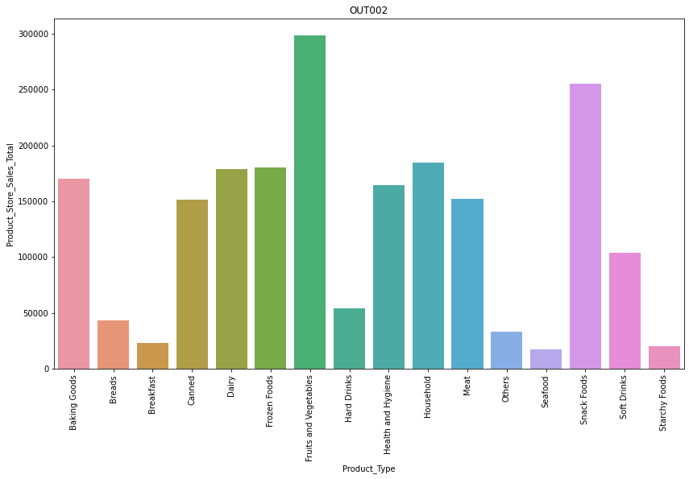

```python
df_OUT002 = (
    data.loc[data["Store_Id"] == "OUT002"]
    .groupby(["Product_Type"], as_index=False)["Product_Store_Sales_Total"]
    .sum()
)
plt.figure(figsize=[14, 8])
plt.xticks(rotation=90)
plt.xlabel("Product_Type")
plt.ylabel("Product_Store_Sales_Total")
plt.title("OUT002")
sns.barplot(x=df_OUT002.Product_Type, y=df_OUT002.Product_Store_Sales_Total)
plt.show()
```

#### OUT003

```python
data.loc[data["Store_Id"] == "OUT003"].describe(include="all").T
```

|  | count | unique | top | freq | mean | std | min | 25% | 50% | 75% | max |
| --- | --- | --- | --- | --- | --- | --- | --- | --- | --- | --- | --- |
| Product_Weight | 1349.0 | NaN | NaN | NaN | 15.103692 | 1.893531 | 7.35 | 14.02 | 15.18 | 16.35 | 22.0 |
| Product_Sugar_Content | 1349 | 3 | Low Sugar | 750 | NaN | NaN | NaN | NaN | NaN | NaN | NaN |
| Product_Allocated_Area | 1349.0 | NaN | NaN | NaN | 0.068637 | 0.048708 | 0.004 | 0.031 | 0.057 | 0.094 | 0.298 |
| Product_Type | 1349 | 16 | Snack Foods | 186 | NaN | NaN | NaN | NaN | NaN | NaN | NaN |
| Product_MRP | 1349.0 | NaN | NaN | NaN | 181.358725 | 24.796429 | 85.88 | 166.92 | 179.67 | 198.07 | 266.0 |
| Store_Id | 1349 | 1 | OUT003 | 1349 | NaN | NaN | NaN | NaN | NaN | NaN | NaN |
| Store_Establishment_Year | 1349.0 | NaN | NaN | NaN | 1999.0 | 0.0 | 1999.0 | 1999.0 | 1999.0 | 1999.0 | 1999.0 |
| Store_Size | 1349 | 1 | Medium | 1349 | NaN | NaN | NaN | NaN | NaN | NaN | NaN |
| Store_Location_City_Type | 1349 | 1 | Tier 1 | 1349 | NaN | NaN | NaN | NaN | NaN | NaN | NaN |
| Store_Type | 1349 | 1 | Departmental Store | 1349 | NaN | NaN | NaN | NaN | NaN | NaN | NaN |
| Product_Store_Sales_Total | 1349.0 | NaN | NaN | NaN | 4946.966323 | 677.539953 | 3069.24 | 4355.39 | 4958.29 | 5366.59 | 8000.0 |
| Product_Id_char | 1349 | 3 | FD | 1024 | NaN | NaN | NaN | NaN | NaN | NaN | NaN |

```python
data.loc[data["Store_Id"] == "OUT003", "Product_Store_Sales_Total"].sum()
```

```
6673457.57
```

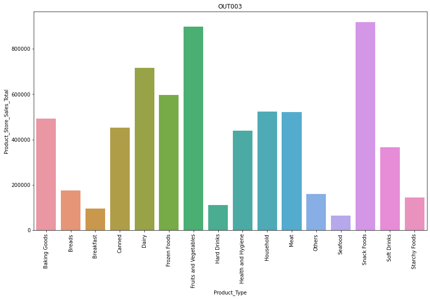

```python
df_OUT003 = (
    data.loc[data["Store_Id"] == "OUT003"]
    .groupby(["Product_Type"], as_index=False)["Product_Store_Sales_Total"]
    .sum()
)
plt.figure(figsize=[14, 8])
plt.xticks(rotation=90)
plt.xlabel("Product_Type")
plt.ylabel("Product_Store_Sales_Total")
plt.title("OUT003")
sns.barplot(x=df_OUT003.Product_Type, y=df_OUT003.Product_Store_Sales_Total)
plt.show()
```

#### OUT004

```python
data.loc[data["Store_Id"] == "OUT004"].describe(include="all").T
```

|  | count | unique | top | freq | mean | std | min | 25% | 50% | 75% | max |
| --- | --- | --- | --- | --- | --- | --- | --- | --- | --- | --- | --- |
| Product_Weight | 4676.0 | NaN | NaN | NaN | 12.349613 | 1.428199 | 7.34 | 11.37 | 12.37 | 13.3025 | 17.79 |
| Product_Sugar_Content | 4676 | 3 | Low Sugar | 2632 | NaN | NaN | NaN | NaN | NaN | NaN | NaN |
| Product_Allocated_Area | 4676.0 | NaN | NaN | NaN | 0.069092 | 0.048584 | 0.004 | 0.031 | 0.056 | 0.097 | 0.297 |
| Product_Type | 4676 | 16 | Fruits and Vegetables | 700 | NaN | NaN | NaN | NaN | NaN | NaN | NaN |
| Product_MRP | 4676.0 | NaN | NaN | NaN | 142.399709 | 17.513973 | 83.04 | 130.54 | 142.82 | 154.1925 | 197.66 |
| Store_Id | 4676 | 1 | OUT004 | 4676 | NaN | NaN | NaN | NaN | NaN | NaN | NaN |
| Store_Establishment_Year | 4676.0 | NaN | NaN | NaN | 2009.0 | 0.0 | 2009.0 | 2009.0 | 2009.0 | 2009.0 | 2009.0 |
| Store_Size | 4676 | 1 | Medium | 4676 | NaN | NaN | NaN | NaN | NaN | NaN | NaN |
| Store_Location_City_Type | 4676 | 1 | Tier 2 | 4676 | NaN | NaN | NaN | NaN | NaN | NaN | NaN |
| Store_Type | 4676 | 1 | Supermarket Type2 | 4676 | NaN | NaN | NaN | NaN | NaN | NaN | NaN |
| Product_Store_Sales_Total | 4676.0 | NaN | NaN | NaN | 3299.312111 | 468.271692 | 1561.06 | 2942.085 | 3304.18 | 3646.9075 | 5462.86 |
| Product_Id_char | 4676 | 3 | FD | 3502 | NaN | NaN | NaN | NaN | NaN | NaN | NaN |

```python
data.loc[data["Store_Id"] == "OUT004", "Product_Store_Sales_Total"].sum()
```

```
15427583.43
```

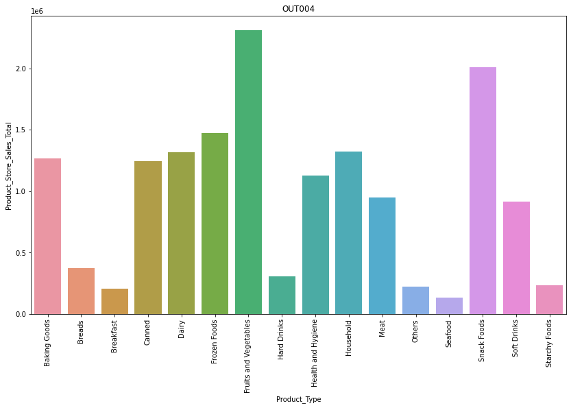

```python
df_OUT004 = (
    data.loc[data["Store_Id"] == "OUT004"]
    .groupby(["Product_Type"], as_index=False)["Product_Store_Sales_Total"]
    .sum()
)
plt.figure(figsize=[14, 8])
plt.xticks(rotation=90)
plt.xlabel("Product_Type")
plt.ylabel("Product_Store_Sales_Total")
plt.title("OUT004")
sns.barplot(x=df_OUT004.Product_Type, y=df_OUT004.Product_Store_Sales_Total)
plt.show()
```

- Q: Which product type has been sold the most number of times in each of the stores? Which product type is contributing the most to the revenue of the individual stores?

**Let's find out the revenue generated by the stores from each of the product types**.

```python
df1 = data.groupby(["Product_Type", "Store_Id"], as_index=False)[
    "Product_Store_Sales_Total"
].sum()
df1
```

|  | Product_Type | Store_Id | Product_Store_Sales_Total |
| --- | --- | --- | --- |
| 0 | Baking Goods | OUT001 | 525131.04 |
| 1 | Baking Goods | OUT002 | 169860.50 |
| 2 | Baking Goods | OUT003 | 491908.20 |
| 3 | Baking Goods | OUT004 | 1266086.26 |
| 4 | Breads | OUT001 | 121274.09 |
| 5 | Breads | OUT002 | 43419.47 |
| 6 | Breads | OUT003 | 175391.93 |
| 7 | Breads | OUT004 | 374856.75 |
| 8 | Breakfast | OUT001 | 38161.10 |
| 9 | Breakfast | OUT002 | 23396.10 |
| 10 | Breakfast | OUT003 | 95634.08 |
| 11 | Breakfast | OUT004 | 204939.13 |
| 12 | Canned | OUT001 | 449016.38 |
| 13 | Canned | OUT002 | 151467.66 |
| 14 | Canned | OUT003 | 452445.17 |
| 15 | Canned | OUT004 | 1247153.50 |
| 16 | Dairy | OUT001 | 598767.62 |
| 17 | Dairy | OUT002 | 178888.18 |
| 18 | Dairy | OUT003 | 715814.94 |
| 19 | Dairy | OUT004 | 1318447.30 |
| 20 | Frozen Foods | OUT001 | 558556.81 |
| 21 | Frozen Foods | OUT002 | 180295.95 |
| 22 | Frozen Foods | OUT003 | 597608.42 |
| 23 | Frozen Foods | OUT004 | 1473519.65 |
| 24 | Fruits and Vegetables | OUT001 | 792992.59 |
| 25 | Fruits and Vegetables | OUT002 | 298503.56 |
| 26 | Fruits and Vegetables | OUT003 | 897437.46 |
| 27 | Fruits and Vegetables | OUT004 | 2311899.66 |
| 28 | Hard Drinks | OUT001 | 152920.74 |
| 29 | Hard Drinks | OUT002 | 54281.85 |
| 30 | Hard Drinks | OUT003 | 110760.30 |
| 31 | Hard Drinks | OUT004 | 307851.73 |
| 32 | Health and Hygiene | OUT001 | 435005.31 |
| 33 | Health and Hygiene | OUT002 | 164660.81 |
| 34 | Health and Hygiene | OUT003 | 439139.18 |
| 35 | Health and Hygiene | OUT004 | 1124901.91 |
| 36 | Household | OUT001 | 531371.38 |
| 37 | Household | OUT002 | 184665.65 |
| 38 | Household | OUT003 | 523981.64 |
| 39 | Household | OUT004 | 1324721.50 |
| 40 | Meat | OUT001 | 505867.28 |
| 41 | Meat | OUT002 | 151800.01 |
| 42 | Meat | OUT003 | 520939.68 |
| 43 | Meat | OUT004 | 950604.97 |
| 44 | Others | OUT001 | 123977.09 |
| 45 | Others | OUT002 | 32835.73 |
| 46 | Others | OUT003 | 159963.75 |
| 47 | Others | OUT004 | 224719.73 |
| 48 | Seafood | OUT001 | 52936.84 |
| 49 | Seafood | OUT002 | 17663.35 |
| 50 | Seafood | OUT003 | 65337.48 |
| 51 | Seafood | OUT004 | 136466.37 |
| 52 | Snack Foods | OUT001 | 806142.24 |
| 53 | Snack Foods | OUT002 | 255317.57 |
| 54 | Snack Foods | OUT003 | 918510.44 |
| 55 | Snack Foods | OUT004 | 2009026.70 |
| 56 | Soft Drinks | OUT001 | 410548.69 |
| 57 | Soft Drinks | OUT002 | 103808.35 |
| 58 | Soft Drinks | OUT003 | 365046.30 |
| 59 | Soft Drinks | OUT004 | 917641.38 |
| 60 | Starchy Foods | OUT001 | 120443.98 |
| 61 | Starchy Foods | OUT002 | 20044.98 |
| 62 | Starchy Foods | OUT003 | 143538.60 |
| 63 | Starchy Foods | OUT004 | 234746.89 |

**Let's find out the revenue generated by the stores from products having different levels of sugar content**.

```python
df2 = data.groupby(["Store_Type", "Product_Sugar_Content"], as_index=False)[
    "Product_Store_Sales_Total"
].sum()
df2
```

|  | Store_Type | Product_Sugar_Content | Product_Store_Sales_Total |
| --- | --- | --- | --- |
| 0 | Departmental Store | Low Sugar | 3706903.24 |
| 1 | Departmental Store | No Sugar | 1123084.57 |
| 2 | Departmental Store | Regular | 1843469.76 |
| 3 | Food Mart | Low Sugar | 1156758.85 |
| 4 | Food Mart | No Sugar | 382162.19 |
| 5 | Food Mart | Regular | 491988.68 |
| 6 | Supermarket Type1 | Low Sugar | 3300834.93 |
| 7 | Supermarket Type1 | No Sugar | 1090353.78 |
| 8 | Supermarket Type1 | Regular | 1831924.47 |
| 9 | Supermarket Type2 | Low Sugar | 8658908.78 |
| 10 | Supermarket Type2 | No Sugar | 2674343.14 |
| 11 | Supermarket Type2 | Regular | 4094331.51 |

## Data Preprocessing

- Missing value treatment (if needed)
- Outlier detection and treatment (if needed)
- Preparing data for modeling
- Any other preprocessing steps (if needed)

## Feature Engineering

**A store which has been in the business for a long duration is more trustworthy than the newly established ones. On the other hand, older stores may sometimes lack infrastructure if proper attention is not given. So let us calculate the current age of the store and incorporate that in our model.**

```python
# Outlet Age
data["Store_Age_Years"] = (
    2021 - data.Store_Establishment_Year
)  ## Fill in the blank and use Store_Establishment_Year to extract the present store age
```

**We have 16 different product types in our dataset. So let us make two broad categories, perishables and non perishables, in order to reduce the number of product types.**

```python
perishables = [
    "Dairy",
    "Meat",
    "Fruits and Vegetables",
    "Breakfast",
    "Breads",
    "Seafood",
]
```

```python
def change(x):
    if x in perishables:
        return "Perishables"
    else:
        return "Non Perishables"


data.Product_Type.apply(change)
```

```
0       Non Perishables
1           Perishables
2       Non Perishables
3       Non Perishables
4       Non Perishables
             ...
8758    Non Perishables
8759    Non Perishables
8760    Non Perishables
8761    Non Perishables
8762    Non Perishables
Name: Product_Type, Length: 8763, dtype: object
```

```python
change1 = []
for i in range(0, len(data)):
    if data.Product_Type[i] in perishables:
        change1.append("Perishables")
    else:
        change1.append("Non Perishables")
```

```python
data["Product_Type_Category"] = pd.Series(
    change1
)  ## Fill in the blank and use change1 to create a new column
```

```python
data.head()
```

|  | Product_Weight | Product_Sugar_Content | Product_Allocated_Area | Product_Type | Product_MRP | Store_Id | Store_Establishment_Year | Store_Size | Store_Location_City_Type | Store_Type | Product_Store_Sales_Total | Product_Id_char | Store_Age_Years | Product_Type_Category |
| --- | --- | --- | --- | --- | --- | --- | --- | --- | --- | --- | --- | --- | --- | --- |
| 0 | 12.66 | Low Sugar | 0.027 | Frozen Foods | 117.08 | OUT004 | 2009 | Medium | Tier 2 | Supermarket Type2 | 2842.40 | FD | 12 | Non Perishables |
| 1 | 16.54 | Low Sugar | 0.144 | Dairy | 171.43 | OUT003 | 1999 | Medium | Tier 1 | Departmental Store | 4830.02 | FD | 22 | Perishables |
| 2 | 14.28 | Regular | 0.031 | Canned | 162.08 | OUT001 | 1987 | High | Tier 2 | Supermarket Type1 | 4130.16 | FD | 34 | Non Perishables |
| 3 | 12.10 | Low Sugar | 0.112 | Baking Goods | 186.31 | OUT001 | 1987 | High | Tier 2 | Supermarket Type1 | 4132.18 | FD | 34 | Non Perishables |
| 4 | 9.57 | No Sugar | 0.010 | Health and Hygiene | 123.67 | OUT002 | 1998 | Small | Tier 3 | Food Mart | 2279.36 | NC | 23 | Non Perishables |

### Missing value Treatment

```python
import missingno as msno
```

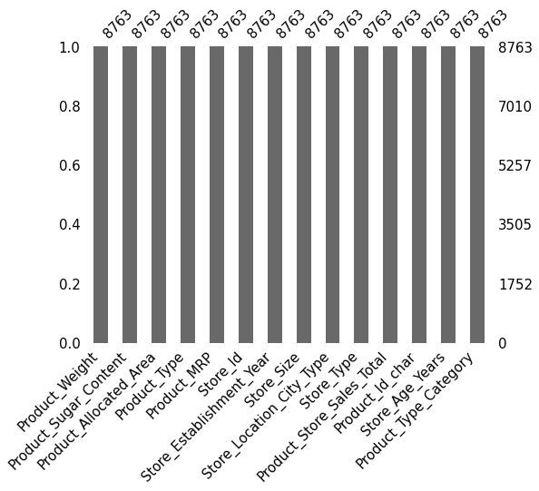

```python
msno.bar(data, figsize=(8, 6), fontsize=15)
plt.show()
```

- There is no missing value in our dataset and it can be seen in the graph above.

```python
data.isnull().sum()
```

```
Product_Weight               0
Product_Sugar_Content        0
Product_Allocated_Area       0
Product_Type                 0
Product_MRP                  0
Store_Id                     0
Store_Establishment_Year     0
Store_Size                   0
Store_Location_City_Type     0
Store_Type                   0
Product_Store_Sales_Total    0
Product_Id_char              0
Store_Age_Years              0
Product_Type_Category        0
dtype: int64
```